# Risk Factor Analysis

## Outcome Variable

**Outcome Variable:** ever_stunted

## Predictor Variables

**Intervention Variable:** perdiar24

**Adjustment Set:**

- arm
- sex
- hfoodsec
- W_birthwt
- W_birthlen
- W_nrooms
- month
- brthmon
- impfloor
- impsan
- safeh20
- delta_hfoodsec
- delta_W_birthwt
- delta_W_birthlen
- delta_W_nrooms
- delta_month
- delta_brthmon
- delta_impfloor
- delta_impsan
- delta_safeh20

## Stratifying Variables

The analysis was stratified on these variable(s):

- agecat
- studyid
- country

## Data Summary

| agecat | studyid | country | perdiar24 | ever_stunted | n_cell | n |
| --- | --- | --- | --- | --- | --- | --- |
| 0-6 months | ki0047075b-MAL-ED | BANGLADESH | Q1 | 0 | 23 | 265 |
| 0-6 months | ki0047075b-MAL-ED | BANGLADESH | Q1 | 1 | 7 | 265 |
| 0-6 months | ki0047075b-MAL-ED | BANGLADESH | Q2 | 0 | 42 | 265 |
| 0-6 months | ki0047075b-MAL-ED | BANGLADESH | Q2 | 1 | 10 | 265 |
| 0-6 months | ki0047075b-MAL-ED | BANGLADESH | Q3 | 0 | 89 | 265 |
| 0-6 months | ki0047075b-MAL-ED | BANGLADESH | Q3 | 1 | 10 | 265 |
| 0-6 months | ki0047075b-MAL-ED | BANGLADESH | Q4 | 0 | 63 | 265 |
| 0-6 months | ki0047075b-MAL-ED | BANGLADESH | Q4 | 1 | 21 | 265 |
| 0-6 months | ki0047075b-MAL-ED | BRAZIL | Q1 | 0 | 135 | 233 |
| 0-6 months | ki0047075b-MAL-ED | BRAZIL | Q1 | 1 | 13 | 233 |
| 0-6 months | ki0047075b-MAL-ED | BRAZIL | Q2 | 0 | 59 | 233 |
| 0-6 months | ki0047075b-MAL-ED | BRAZIL | Q2 | 1 | 11 | 233 |
| 0-6 months | ki0047075b-MAL-ED | BRAZIL | Q3 | 0 | 13 | 233 |
| 0-6 months | ki0047075b-MAL-ED | BRAZIL | Q3 | 1 | 1 | 233 |
| 0-6 months | ki0047075b-MAL-ED | BRAZIL | Q4 | 0 | 1 | 233 |
| 0-6 months | ki0047075b-MAL-ED | BRAZIL | Q4 | 1 | 0 | 233 |
| 0-6 months | ki0047075b-MAL-ED | INDIA | Q1 | 0 | 30 | 251 |
| 0-6 months | ki0047075b-MAL-ED | INDIA | Q1 | 1 | 6 | 251 |
| 0-6 months | ki0047075b-MAL-ED | INDIA | Q2 | 0 | 67 | 251 |
| 0-6 months | ki0047075b-MAL-ED | INDIA | Q2 | 1 | 12 | 251 |
| 0-6 months | ki0047075b-MAL-ED | INDIA | Q3 | 0 | 82 | 251 |
| 0-6 months | ki0047075b-MAL-ED | INDIA | Q3 | 1 | 17 | 251 |
| 0-6 months | ki0047075b-MAL-ED | INDIA | Q4 | 0 | 30 | 251 |
| 0-6 months | ki0047075b-MAL-ED | INDIA | Q4 | 1 | 7 | 251 |
| 0-6 months | ki0047075b-MAL-ED | NEPAL | Q1 | 0 | 24 | 240 |
| 0-6 months | ki0047075b-MAL-ED | NEPAL | Q1 | 1 | 4 | 240 |
| 0-6 months | ki0047075b-MAL-ED | NEPAL | Q2 | 0 | 61 | 240 |
| 0-6 months | ki0047075b-MAL-ED | NEPAL | Q2 | 1 | 5 | 240 |
| 0-6 months | ki0047075b-MAL-ED | NEPAL | Q3 | 0 | 66 | 240 |
| 0-6 months | ki0047075b-MAL-ED | NEPAL | Q3 | 1 | 9 | 240 |

[output cut: 466 more lines]

The following strata were considered:

- agecat: 0-24 months, studyid: ki0047075b-MAL-ED, country: BANGLADESH
- agecat: 0-24 months, studyid: ki0047075b-MAL-ED, country: BRAZIL
- agecat: 0-24 months, studyid: ki0047075b-MAL-ED, country: INDIA
- agecat: 0-24 months, studyid: ki0047075b-MAL-ED, country: NEPAL
- agecat: 0-24 months, studyid: ki0047075b-MAL-ED, country: PERU
- agecat: 0-24 months, studyid: ki0047075b-MAL-ED, country: SOUTH AFRICA
- agecat: 0-24 months, studyid: ki0047075b-MAL-ED, country: TANZANIA, UNITED REPUBLIC OF
- agecat: 0-24 months, studyid: ki1000109-EE, country: PAKISTAN
- agecat: 0-24 months, studyid: ki1000109-ResPak, country: PAKISTAN
- agecat: 0-24 months, studyid: ki1000304b-SAS-FoodSuppl, country: INDIA
- agecat: 0-24 months, studyid: ki1017093-NIH-Birth, country: BANGLADESH
- agecat: 0-24 months, studyid: ki1017093b-PROVIDE, country: BANGLADESH
- agecat: 0-24 months, studyid: ki1017093c-NIH-Crypto, country: BANGLADESH
- agecat: 0-24 months, studyid: ki1112895-Guatemala BSC, country: GUATEMALA
- agecat: 0-24 months, studyid: ki1112895-iLiNS-Zinc, country: BURKINA FASO
- agecat: 0-24 months, studyid: ki1114097-CMIN, country: BANGLADESH
- agecat: 0-24 months, studyid: ki1114097-CMIN, country: BRAZIL
- agecat: 0-24 months, studyid: ki1114097-CMIN, country: GUINEA-BISSAU
- agecat: 0-24 months, studyid: ki1114097-CMIN, country: PERU
- agecat: 0-24 months, studyid: ki1114097-CONTENT, country: PERU
- agecat: 0-24 months, studyid: kiGH5241-JiVitA-4, country: BANGLADESH
- agecat: 0-6 months, studyid: ki0047075b-MAL-ED, country: BANGLADESH
- agecat: 0-6 months, studyid: ki0047075b-MAL-ED, country: BRAZIL
- agecat: 0-6 months, studyid: ki0047075b-MAL-ED, country: INDIA
- agecat: 0-6 months, studyid: ki0047075b-MAL-ED, country: NEPAL
- agecat: 0-6 months, studyid: ki0047075b-MAL-ED, country: PERU
- agecat: 0-6 months, studyid: ki0047075b-MAL-ED, country: SOUTH AFRICA
- agecat: 0-6 months, studyid: ki0047075b-MAL-ED, country: TANZANIA, UNITED REPUBLIC OF
- agecat: 0-6 months, studyid: ki1000109-EE, country: PAKISTAN
- agecat: 0-6 months, studyid: ki1000109-ResPak, country: PAKISTAN
- agecat: 0-6 months, studyid: ki1000304b-SAS-FoodSuppl, country: INDIA
- agecat: 0-6 months, studyid: ki1017093-NIH-Birth, country: BANGLADESH
- agecat: 0-6 months, studyid: ki1017093b-PROVIDE, country: BANGLADESH
- agecat: 0-6 months, studyid: ki1017093c-NIH-Crypto, country: BANGLADESH
- agecat: 0-6 months, studyid: ki1112895-Guatemala BSC, country: GUATEMALA
- agecat: 0-6 months, studyid: ki1114097-CMIN, country: BANGLADESH
- agecat: 0-6 months, studyid: ki1114097-CMIN, country: BRAZIL
- agecat: 0-6 months, studyid: ki1114097-CMIN, country: GUINEA-BISSAU
- agecat: 0-6 months, studyid: ki1114097-CMIN, country: PERU
- agecat: 0-6 months, studyid: ki1114097-CONTENT, country: PERU
- agecat: 0-6 months, studyid: kiGH5241-JiVitA-4, country: BANGLADESH
- agecat: 6-24 months, studyid: ki0047075b-MAL-ED, country: BANGLADESH
- agecat: 6-24 months, studyid: ki0047075b-MAL-ED, country: BRAZIL
- agecat: 6-24 months, studyid: ki0047075b-MAL-ED, country: INDIA
- agecat: 6-24 months, studyid: ki0047075b-MAL-ED, country: NEPAL
- agecat: 6-24 months, studyid: ki0047075b-MAL-ED, country: PERU
- agecat: 6-24 months, studyid: ki0047075b-MAL-ED, country: SOUTH AFRICA
- agecat: 6-24 months, studyid: ki0047075b-MAL-ED, country: TANZANIA, UNITED REPUBLIC OF
- agecat: 6-24 months, studyid: ki1000109-EE, country: PAKISTAN
- agecat: 6-24 months, studyid: ki1000109-ResPak, country: PAKISTAN
- agecat: 6-24 months, studyid: ki1000304b-SAS-FoodSuppl, country: INDIA
- agecat: 6-24 months, studyid: ki1017093-NIH-Birth, country: BANGLADESH
- agecat: 6-24 months, studyid: ki1017093b-PROVIDE, country: BANGLADESH
- agecat: 6-24 months, studyid: ki1017093c-NIH-Crypto, country: BANGLADESH
- agecat: 6-24 months, studyid: ki1112895-Guatemala BSC, country: GUATEMALA
- agecat: 6-24 months, studyid: ki1112895-iLiNS-Zinc, country: BURKINA FASO
- agecat: 6-24 months, studyid: ki1114097-CMIN, country: BANGLADESH
- agecat: 6-24 months, studyid: ki1114097-CMIN, country: BRAZIL
- agecat: 6-24 months, studyid: ki1114097-CMIN, country: GUINEA-BISSAU
- agecat: 6-24 months, studyid: ki1114097-CMIN, country: PERU
- agecat: 6-24 months, studyid: ki1114097-CONTENT, country: PERU
- agecat: 6-24 months, studyid: kiGH5241-JiVitA-4, country: BANGLADESH

### Dropped Strata

Some strata were dropped due to rare outcomes:

- agecat: 0-6 months, studyid: ki0047075b-MAL-ED, country: BRAZIL
- agecat: 0-6 months, studyid: ki0047075b-MAL-ED, country: NEPAL
- agecat: 0-6 months, studyid: ki0047075b-MAL-ED, country: PERU
- agecat: 0-6 months, studyid: ki0047075b-MAL-ED, country: SOUTH AFRICA
- agecat: 0-6 months, studyid: ki1000109-ResPak, country: PAKISTAN
- agecat: 0-6 months, studyid: ki1000304b-SAS-FoodSuppl, country: INDIA
- agecat: 0-6 months, studyid: ki1112895-Guatemala BSC, country: GUATEMALA
- agecat: 0-6 months, studyid: ki1114097-CMIN, country: BRAZIL
- agecat: 0-6 months, studyid: ki1114097-CMIN, country: PERU
- agecat: 0-6 months, studyid: ki1114097-CONTENT, country: PERU
- agecat: 6-24 months, studyid: ki0047075b-MAL-ED, country: BANGLADESH
- agecat: 6-24 months, studyid: ki0047075b-MAL-ED, country: BRAZIL
- agecat: 6-24 months, studyid: ki0047075b-MAL-ED, country: NEPAL
- agecat: 6-24 months, studyid: ki0047075b-MAL-ED, country: PERU
- agecat: 6-24 months, studyid: ki0047075b-MAL-ED, country: SOUTH AFRICA
- agecat: 6-24 months, studyid: ki1000109-EE, country: PAKISTAN
- agecat: 6-24 months, studyid: ki1000109-ResPak, country: PAKISTAN
- agecat: 6-24 months, studyid: ki1112895-Guatemala BSC, country: GUATEMALA
- agecat: 6-24 months, studyid: ki1114097-CMIN, country: BANGLADESH
- agecat: 6-24 months, studyid: ki1114097-CMIN, country: BRAZIL
- agecat: 6-24 months, studyid: ki1114097-CONTENT, country: PERU
- agecat: 0-24 months, studyid: ki0047075b-MAL-ED, country: BRAZIL
- agecat: 0-24 months, studyid: ki0047075b-MAL-ED, country: NEPAL
- agecat: 0-24 months, studyid: ki0047075b-MAL-ED, country: SOUTH AFRICA
- agecat: 0-24 months, studyid: ki1000109-EE, country: PAKISTAN
- agecat: 0-24 months, studyid: ki1114097-CMIN, country: BRAZIL

## Methods Detail

We’re interested in the causal parameters $E[Y_a]$ for all values of $a \in \mathcal{A}$. These parameters represent the mean outcome if, possibly contrary to fact, we intervened to set all units to have $A=a$. Under the randomization and positivity assumptions, these are identified by the statistical parameters $\psi_a=E_W[E_{Y|A,W}(Y|A=a,W)]$. In addition, we’re interested in the mean of $Y$, $E[Y]$ under no intervention (the observed mean). We will estimate these parameters by using SuperLearner to fit the relevant likelihood factors – $E_{Y|A,W}(Y|A=a,W)$ and $p(A=a|W)$, and then updating our likelihood fit using a joint TMLE.

For unadjusted analyses ($W=\{\}$), initial likelihoods were estimated using Lrnr_glm to estimate the simple $E(Y|A)$ and Lrnr_mean to estimate $p(A)$. For adjusted analyses, a small library containing Lrnr_glmnet, Lrnr_xgboost, and Lrnr_mean was used.

Having estimated these parameters, we will then use the delta method to estimate relative risks and attributable risks relative to a prespecified baseline level of $A$.

# Results Detail

## Results Plots

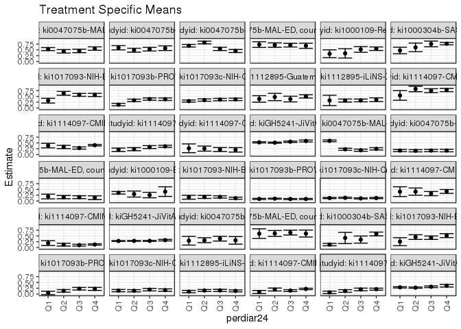

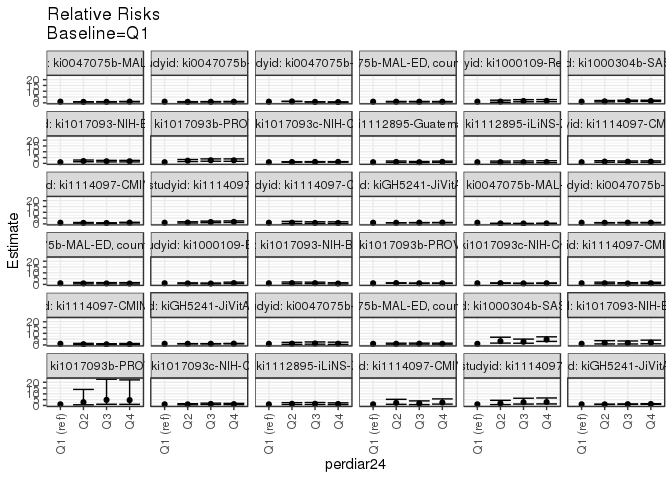

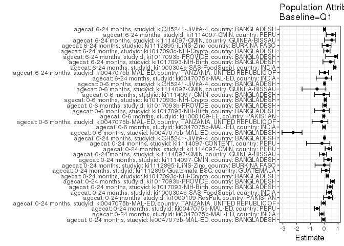

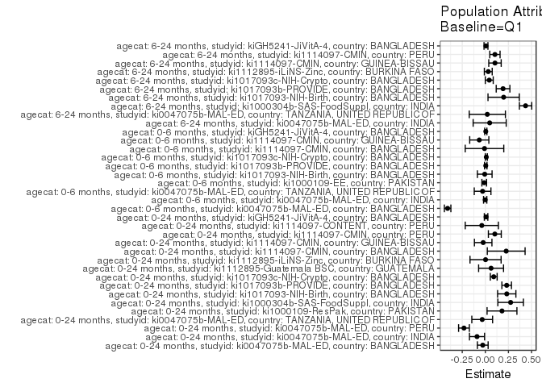

## Results Table

### Parameter: TSM

| agecat | studyid | country | intervention_level | baseline_level | estimate | ci_lower | ci_upper |
| --- | --- | --- | --- | --- | --- | --- | --- |
| 0-24 months | ki0047075b-MAL-ED | BANGLADESH | Q1 | NA | 0.5336079 | 0.4683833 | 0.5988325 |
| 0-24 months | ki0047075b-MAL-ED | BANGLADESH | Q2 | NA | 0.4376636 | 0.3619133 | 0.5134139 |
| 0-24 months | ki0047075b-MAL-ED | BANGLADESH | Q3 | NA | 0.4550461 | 0.3804124 | 0.5296798 |
| 0-24 months | ki0047075b-MAL-ED | BANGLADESH | Q4 | NA | 0.5561464 | 0.4820359 | 0.6302570 |
| 0-24 months | ki0047075b-MAL-ED | INDIA | Q1 | NA | 0.5919832 | 0.5004592 | 0.6835072 |
| 0-24 months | ki0047075b-MAL-ED | INDIA | Q2 | NA | 0.4848143 | 0.4003789 | 0.5692498 |
| 0-24 months | ki0047075b-MAL-ED | INDIA | Q3 | NA | 0.5290474 | 0.4503313 | 0.6077635 |
| 0-24 months | ki0047075b-MAL-ED | INDIA | Q4 | NA | 0.5727395 | 0.4728298 | 0.6726493 |
| 0-24 months | ki0047075b-MAL-ED | PERU | Q1 | NA | 0.6801058 | 0.6232929 | 0.7369188 |
| 0-24 months | ki0047075b-MAL-ED | PERU | Q2 | NA | 0.8175407 | 0.7587768 | 0.8763046 |
| 0-24 months | ki0047075b-MAL-ED | PERU | Q3 | NA | 0.5416571 | 0.4718001 | 0.6115141 |
| 0-24 months | ki0047075b-MAL-ED | PERU | Q4 | NA | 0.4531557 | 0.3878308 | 0.5184807 |
| 0-24 months | ki0047075b-MAL-ED | TANZANIA, UNITED REPUBLIC OF | Q1 | NA | 0.7284795 | 0.6068827 | 0.8500763 |
| 0-24 months | ki0047075b-MAL-ED | TANZANIA, UNITED REPUBLIC OF | Q2 | NA | 0.7070752 | 0.6114699 | 0.8026804 |
| 0-24 months | ki0047075b-MAL-ED | TANZANIA, UNITED REPUBLIC OF | Q3 | NA | 0.7035857 | 0.6242256 | 0.7829457 |
| 0-24 months | ki0047075b-MAL-ED | TANZANIA, UNITED REPUBLIC OF | Q4 | NA | 0.6769838 | 0.5656694 | 0.7882983 |
| 0-24 months | ki1000109-ResPak | PAKISTAN | Q1 | NA | 0.3322545 | 0.1627446 | 0.5017643 |
| 0-24 months | ki1000109-ResPak | PAKISTAN | Q2 | NA | 0.3509450 | 0.1493061 | 0.5525840 |
| 0-24 months | ki1000109-ResPak | PAKISTAN | Q3 | NA | 0.5186392 | 0.3956616 | 0.6416168 |
| 0-24 months | ki1000109-ResPak | PAKISTAN | Q4 | NA | 0.5499396 | 0.4738377 | 0.6260416 |
| 0-24 months | ki1000304b-SAS-FoodSuppl | INDIA | Q1 | NA | 0.4725651 | 0.3314034 | 0.6137268 |
| 0-24 months | ki1000304b-SAS-FoodSuppl | INDIA | Q2 | NA | 0.6076806 | 0.4215391 | 0.7938221 |
| 0-24 months | ki1000304b-SAS-FoodSuppl | INDIA | Q3 | NA | 0.7562939 | 0.6331813 | 0.8794066 |
| 0-24 months | ki1000304b-SAS-FoodSuppl | INDIA | Q4 | NA | 0.7677646 | 0.7150013 | 0.8205278 |
| 0-24 months | ki1017093-NIH-Birth | BANGLADESH | Q1 | NA | 0.3145165 | 0.2108545 | 0.4181785 |
| 0-24 months | ki1017093-NIH-Birth | BANGLADESH | Q2 | NA | 0.6318385 | 0.5497656 | 0.7139113 |
| 0-24 months | ki1017093-NIH-Birth | BANGLADESH | Q3 | NA | 0.5668218 | 0.5035843 | 0.6300593 |
| 0-24 months | ki1017093-NIH-Birth | BANGLADESH | Q4 | NA | 0.5633617 | 0.4944336 | 0.6322899 |
| 0-24 months | ki1017093b-PROVIDE | BANGLADESH | Q1 | NA | 0.1447724 | 0.0915564 | 0.1979884 |
| 0-24 months | ki1017093b-PROVIDE | BANGLADESH | Q2 | NA | 0.3281118 | 0.2735843 | 0.3826393 |

[output cut: 114 more lines]

### Parameter: E(Y)

| agecat | studyid | country | intervention_level | baseline_level | estimate | ci_lower | ci_upper |
| --- | --- | --- | --- | --- | --- | --- | --- |
| 0-24 months | ki0047075b-MAL-ED | BANGLADESH | NA | NA | 0.5056604 | 0.4453505 | 0.5659702 |
| 0-24 months | ki0047075b-MAL-ED | INDIA | NA | NA | 0.5019920 | 0.4400130 | 0.5639710 |
| 0-24 months | ki0047075b-MAL-ED | PERU | NA | NA | 0.4488449 | 0.3927492 | 0.5049406 |
| 0-24 months | ki0047075b-MAL-ED | TANZANIA, UNITED REPUBLIC OF | NA | NA | 0.6946565 | 0.6387828 | 0.7505302 |
| 0-24 months | ki1000109-ResPak | PAKISTAN | NA | NA | 0.5126354 | 0.4536662 | 0.5716045 |
| 0-24 months | ki1000304b-SAS-FoodSuppl | INDIA | NA | NA | 0.7464115 | 0.7046540 | 0.7881689 |
| 0-24 months | ki1017093-NIH-Birth | BANGLADESH | NA | NA | 0.5463259 | 0.5072952 | 0.5853565 |
| 0-24 months | ki1017093b-PROVIDE | BANGLADESH | NA | NA | 0.3757143 | 0.3398113 | 0.4116172 |
| 0-24 months | ki1017093c-NIH-Crypto | BANGLADESH | NA | NA | 0.3878628 | 0.3531521 | 0.4225735 |
| 0-24 months | ki1112895-Guatemala BSC | GUATEMALA | NA | NA | 0.4530744 | 0.3974812 | 0.5086676 |
| 0-24 months | ki1112895-iLiNS-Zinc | BURKINA FASO | NA | NA | 0.3274878 | 0.2607918 | 0.3941837 |
| 0-24 months | ki1114097-CMIN | BANGLADESH | NA | NA | 0.7653430 | 0.7153466 | 0.8153393 |
| 0-24 months | ki1114097-CMIN | GUINEA-BISSAU | NA | NA | 0.3612991 | 0.3368005 | 0.3857976 |
| 0-24 months | ki1114097-CMIN | PERU | NA | NA | 0.3057051 | 0.2760637 | 0.3353464 |
| 0-24 months | ki1114097-CONTENT | PERU | NA | NA | 0.2279070 | 0.1717046 | 0.2841094 |
| 0-24 months | kiGH5241-JiVitA-4 | BANGLADESH | NA | NA | 0.5316060 | 0.5154292 | 0.5477829 |
| 0-6 months | ki0047075b-MAL-ED | BANGLADESH | NA | NA | 0.1811321 | 0.1346751 | 0.2275890 |
| 0-6 months | ki0047075b-MAL-ED | INDIA | NA | NA | 0.1673307 | 0.1210604 | 0.2136010 |
| 0-6 months | ki0047075b-MAL-ED | TANZANIA, UNITED REPUBLIC OF | NA | NA | 0.1641221 | 0.1191873 | 0.2090569 |
| 0-6 months | ki1000109-EE | PAKISTAN | NA | NA | 0.3430079 | 0.2951521 | 0.3908637 |
| 0-6 months | ki1017093-NIH-Birth | BANGLADESH | NA | NA | 0.1565495 | 0.1280614 | 0.1850376 |
| 0-6 months | ki1017093b-PROVIDE | BANGLADESH | NA | NA | 0.0942857 | 0.0726222 | 0.1159492 |
| 0-6 months | ki1017093c-NIH-Crypto | BANGLADESH | NA | NA | 0.1385224 | 0.1139141 | 0.1631308 |
| 0-6 months | ki1114097-CMIN | BANGLADESH | NA | NA | 0.3935018 | 0.3358674 | 0.4511362 |
| 0-6 months | ki1114097-CMIN | GUINEA-BISSAU | NA | NA | 0.1259259 | 0.1047621 | 0.1470897 |
| 0-6 months | kiGH5241-JiVitA-4 | BANGLADESH | NA | NA | 0.2867446 | 0.2729319 | 0.3005573 |
| 6-24 months | ki0047075b-MAL-ED | INDIA | NA | NA | 0.3402062 | 0.2733649 | 0.4070475 |
| 6-24 months | ki0047075b-MAL-ED | TANZANIA, UNITED REPUBLIC OF | NA | NA | 0.6203209 | 0.5505766 | 0.6900651 |
| 6-24 months | ki1000304b-SAS-FoodSuppl | INDIA | NA | NA | 0.5619469 | 0.4971181 | 0.6267757 |
| 6-24 months | ki1017093-NIH-Birth | BANGLADESH | NA | NA | 0.4500000 | 0.4023647 | 0.4976353 |
| 6-24 months | ki1017093b-PROVIDE | BANGLADESH | NA | NA | 0.2394366 | 0.2018814 | 0.2769918 |
| 6-24 months | ki1017093c-NIH-Crypto | BANGLADESH | NA | NA | 0.1887097 | 0.1578857 | 0.2195336 |
| 6-24 months | ki1112895-iLiNS-Zinc | BURKINA FASO | NA | NA | 0.1377778 | 0.1091390 | 0.1664166 |
| 6-24 months | ki1114097-CMIN | GUINEA-BISSAU | NA | NA | 0.1902834 | 0.1683827 | 0.2121841 |
| 6-24 months | ki1114097-CMIN | PERU | NA | NA | 0.1755319 | 0.1483241 | 0.2027397 |
| 6-24 months | kiGH5241-JiVitA-4 | BANGLADESH | NA | NA | 0.2949907 | 0.2786334 | 0.3113480 |

### Parameter: RR

| agecat | studyid | country | intervention_level | baseline_level | estimate | ci_lower | ci_upper |
| --- | --- | --- | --- | --- | --- | --- | --- |
| 0-24 months | ki0047075b-MAL-ED | BANGLADESH | Q1 | Q1 | 1.0000000 | 1.0000000 | 1.0000000 |
| 0-24 months | ki0047075b-MAL-ED | BANGLADESH | Q2 | Q1 | 0.8201969 | 0.6874968 | 0.9785107 |
| 0-24 months | ki0047075b-MAL-ED | BANGLADESH | Q3 | Q1 | 0.8527723 | 0.7195713 | 1.0106305 |
| 0-24 months | ki0047075b-MAL-ED | BANGLADESH | Q4 | Q1 | 1.0422379 | 0.9002495 | 1.2066210 |
| 0-24 months | ki0047075b-MAL-ED | INDIA | Q1 | Q1 | 1.0000000 | 1.0000000 | 1.0000000 |
| 0-24 months | ki0047075b-MAL-ED | INDIA | Q2 | Q1 | 0.8189664 | 0.6631730 | 1.0113590 |
| 0-24 months | ki0047075b-MAL-ED | INDIA | Q3 | Q1 | 0.8936865 | 0.7392892 | 1.0803290 |
| 0-24 months | ki0047075b-MAL-ED | INDIA | Q4 | Q1 | 0.9674929 | 0.7809836 | 1.1985430 |
| 0-24 months | ki0047075b-MAL-ED | PERU | Q1 | Q1 | 1.0000000 | 1.0000000 | 1.0000000 |
| 0-24 months | ki0047075b-MAL-ED | PERU | Q2 | Q1 | 1.2020786 | 1.0909785 | 1.3244927 |
| 0-24 months | ki0047075b-MAL-ED | PERU | Q3 | Q1 | 0.7964306 | 0.6959888 | 0.9113677 |
| 0-24 months | ki0047075b-MAL-ED | PERU | Q4 | Q1 | 0.6663018 | 0.5760178 | 0.7707367 |
| 0-24 months | ki0047075b-MAL-ED | TANZANIA, UNITED REPUBLIC OF | Q1 | Q1 | 1.0000000 | 1.0000000 | 1.0000000 |
| 0-24 months | ki0047075b-MAL-ED | TANZANIA, UNITED REPUBLIC OF | Q2 | Q1 | 0.9706178 | 0.7858014 | 1.1989020 |
| 0-24 months | ki0047075b-MAL-ED | TANZANIA, UNITED REPUBLIC OF | Q3 | Q1 | 0.9658277 | 0.7931757 | 1.1760611 |
| 0-24 months | ki0047075b-MAL-ED | TANZANIA, UNITED REPUBLIC OF | Q4 | Q1 | 0.9293108 | 0.7382884 | 1.1697576 |
| 0-24 months | ki1000109-ResPak | PAKISTAN | Q1 | Q1 | 1.0000000 | 1.0000000 | 1.0000000 |
| 0-24 months | ki1000109-ResPak | PAKISTAN | Q2 | Q1 | 1.0562538 | 0.4906667 | 2.2737881 |
| 0-24 months | ki1000109-ResPak | PAKISTAN | Q3 | Q1 | 1.5609699 | 0.8888507 | 2.7413232 |
| 0-24 months | ki1000109-ResPak | PAKISTAN | Q4 | Q1 | 1.6551761 | 0.9757593 | 2.8076676 |
| 0-24 months | ki1000304b-SAS-FoodSuppl | INDIA | Q1 | Q1 | 1.0000000 | 1.0000000 | 1.0000000 |
| 0-24 months | ki1000304b-SAS-FoodSuppl | INDIA | Q2 | Q1 | 1.2859194 | 0.8366844 | 1.9763589 |
| 0-24 months | ki1000304b-SAS-FoodSuppl | INDIA | Q3 | Q1 | 1.6004017 | 1.1383031 | 2.2500909 |
| 0-24 months | ki1000304b-SAS-FoodSuppl | INDIA | Q4 | Q1 | 1.6246748 | 1.1971120 | 2.2049466 |
| 0-24 months | ki1017093-NIH-Birth | BANGLADESH | Q1 | Q1 | 1.0000000 | 1.0000000 | 1.0000000 |
| 0-24 months | ki1017093-NIH-Birth | BANGLADESH | Q2 | Q1 | 2.0089199 | 1.4102119 | 2.8618105 |
| 0-24 months | ki1017093-NIH-Birth | BANGLADESH | Q3 | Q1 | 1.8022007 | 1.2730380 | 2.5513200 |
| 0-24 months | ki1017093-NIH-Birth | BANGLADESH | Q4 | Q1 | 1.7911993 | 1.2608116 | 2.5447061 |
| 0-24 months | ki1017093b-PROVIDE | BANGLADESH | Q1 | Q1 | 1.0000000 | 1.0000000 | 1.0000000 |
| 0-24 months | ki1017093b-PROVIDE | BANGLADESH | Q2 | Q1 | 2.2663976 | 1.5364864 | 3.3430548 |

[output cut: 114 more lines]

### Parameter: PAR

| agecat | studyid | country | intervention_level | baseline_level | estimate | ci_lower | ci_upper |
| --- | --- | --- | --- | --- | --- | --- | --- |
| 0-24 months | ki0047075b-MAL-ED | BANGLADESH | Q1 | NA | -0.0279476 | -0.0861566 | 0.0302615 |
| 0-24 months | ki0047075b-MAL-ED | INDIA | Q1 | NA | -0.0899912 | -0.1717728 | -0.0082095 |
| 0-24 months | ki0047075b-MAL-ED | PERU | Q1 | NA | -0.2312610 | -0.2894421 | -0.1730798 |
| 0-24 months | ki0047075b-MAL-ED | TANZANIA, UNITED REPUBLIC OF | Q1 | NA | -0.0338230 | -0.1462525 | 0.0786066 |
| 0-24 months | ki1000109-ResPak | PAKISTAN | Q1 | NA | 0.1803809 | 0.0188216 | 0.3419403 |
| 0-24 months | ki1000304b-SAS-FoodSuppl | INDIA | Q1 | NA | 0.2738464 | 0.1356132 | 0.4120795 |
| 0-24 months | ki1017093-NIH-Birth | BANGLADESH | Q1 | NA | 0.2318094 | 0.1328214 | 0.3307973 |
| 0-24 months | ki1017093b-PROVIDE | BANGLADESH | Q1 | NA | 0.2309419 | 0.1790904 | 0.2827934 |
| 0-24 months | ki1017093c-NIH-Crypto | BANGLADESH | Q1 | NA | 0.0908970 | 0.0540636 | 0.1277304 |
| 0-24 months | ki1112895-Guatemala BSC | GUATEMALA | Q1 | NA | 0.0622987 | -0.0725138 | 0.1971111 |
| 0-24 months | ki1112895-iLiNS-Zinc | BURKINA FASO | Q1 | NA | 0.0023570 | -0.1659304 | 0.1706443 |
| 0-24 months | ki1114097-CMIN | BANGLADESH | Q1 | NA | 0.2257468 | 0.0211803 | 0.4303134 |
| 0-24 months | ki1114097-CMIN | GUINEA-BISSAU | Q1 | NA | -0.0233725 | -0.1182153 | 0.0714704 |
| 0-24 months | ki1114097-CMIN | PERU | Q1 | NA | 0.1027000 | 0.0329654 | 0.1724347 |
| 0-24 months | ki1114097-CONTENT | PERU | Q1 | NA | -0.0381779 | -0.2175856 | 0.1412299 |
| 0-24 months | kiGH5241-JiVitA-4 | BANGLADESH | Q1 | NA | 0.0079670 | -0.0110947 | 0.0270287 |
| 0-6 months | ki0047075b-MAL-ED | BANGLADESH | Q1 | NA | -0.4082279 | -0.4434426 | -0.3730132 |
| 0-6 months | ki0047075b-MAL-ED | INDIA | Q1 | NA | -0.0016001 | -0.0193427 | 0.0161426 |
| 0-6 months | ki0047075b-MAL-ED | TANZANIA, UNITED REPUBLIC OF | Q1 | NA | -0.0297189 | -0.1200772 | 0.0606394 |
| 0-6 months | ki1000109-EE | PAKISTAN | Q1 | NA | -0.0119523 | -0.0373652 | 0.0134606 |
| 0-6 months | ki1017093-NIH-Birth | BANGLADESH | Q1 | NA | -0.0066196 | -0.0861224 | 0.0728832 |
| 0-6 months | ki1017093b-PROVIDE | BANGLADESH | Q1 | NA | 0.0045954 | -0.0087844 | 0.0179753 |
| 0-6 months | ki1017093c-NIH-Crypto | BANGLADESH | Q1 | NA | 0.0105945 | -0.0006270 | 0.0218159 |
| 0-6 months | ki1114097-CMIN | BANGLADESH | Q1 | NA | -0.0090271 | -0.2177718 | 0.1997176 |
| 0-6 months | ki1114097-CMIN | GUINEA-BISSAU | Q1 | NA | -0.0655414 | -0.1690553 | 0.0379725 |
| 0-6 months | kiGH5241-JiVitA-4 | BANGLADESH | Q1 | NA | 0.0048978 | -0.0071767 | 0.0169722 |
| 6-24 months | ki0047075b-MAL-ED | INDIA | Q1 | NA | 0.0469152 | -0.1319999 | 0.2258302 |
| 6-24 months | ki0047075b-MAL-ED | TANZANIA, UNITED REPUBLIC OF | Q1 | NA | 0.0214082 | -0.1743930 | 0.2172095 |
| 6-24 months | ki1000304b-SAS-FoodSuppl | INDIA | Q1 | NA | 0.4354589 | 0.3686473 | 0.5022706 |
| 6-24 months | ki1017093-NIH-Birth | BANGLADESH | Q1 | NA | 0.1981760 | 0.0288544 | 0.3674976 |
| 6-24 months | ki1017093b-PROVIDE | BANGLADESH | Q1 | NA | 0.1917430 | 0.1176863 | 0.2657996 |
| 6-24 months | ki1017093c-NIH-Crypto | BANGLADESH | Q1 | NA | 0.0424104 | -0.0005678 | 0.0853885 |
| 6-24 months | ki1112895-iLiNS-Zinc | BURKINA FASO | Q1 | NA | 0.0317329 | -0.0108371 | 0.0743029 |
| 6-24 months | ki1114097-CMIN | GUINEA-BISSAU | Q1 | NA | 0.1044043 | 0.0371771 | 0.1716316 |
| 6-24 months | ki1114097-CMIN | PERU | Q1 | NA | 0.1037167 | 0.0480714 | 0.1593620 |
| 6-24 months | kiGH5241-JiVitA-4 | BANGLADESH | Q1 | NA | 0.0069181 | -0.0143386 | 0.0281748 |

### Parameter: PAF

| agecat | studyid | country | intervention_level | baseline_level | estimate | ci_lower | ci_upper |
| --- | --- | --- | --- | --- | --- | --- | --- |
| 0-24 months | ki0047075b-MAL-ED | BANGLADESH | Q1 | NA | -0.0552694 | -0.1799772 | 0.0562584 |
| 0-24 months | ki0047075b-MAL-ED | INDIA | Q1 | NA | -0.1792681 | -0.3609829 | -0.0218154 |
| 0-24 months | ki0047075b-MAL-ED | PERU | Q1 | NA | -0.5152358 | -0.6967750 | -0.3531197 |
| 0-24 months | ki0047075b-MAL-ED | TANZANIA, UNITED REPUBLIC OF | Q1 | NA | -0.0486902 | -0.2241070 | 0.1015890 |
| 0-24 months | ki1000109-ResPak | PAKISTAN | Q1 | NA | 0.3518698 | -0.0553017 | 0.6019406 |
| 0-24 months | ki1000304b-SAS-FoodSuppl | INDIA | Q1 | NA | 0.3668840 | 0.1524356 | 0.5270732 |
| 0-24 months | ki1017093-NIH-Birth | BANGLADESH | Q1 | NA | 0.4243061 | 0.2109855 | 0.5799526 |
| 0-24 months | ki1017093b-PROVIDE | BANGLADESH | Q1 | NA | 0.6146743 | 0.4568002 | 0.7266643 |
| 0-24 months | ki1017093c-NIH-Crypto | BANGLADESH | Q1 | NA | 0.2343535 | 0.1352157 | 0.3221263 |
| 0-24 months | ki1112895-Guatemala BSC | GUATEMALA | Q1 | NA | 0.1375020 | -0.2159676 | 0.3882216 |
| 0-24 months | ki1112895-iLiNS-Zinc | BURKINA FASO | Q1 | NA | 0.0071972 | -0.6677914 | 0.4090043 |
| 0-24 months | ki1114097-CMIN | BANGLADESH | Q1 | NA | 0.2949617 | -0.0294422 | 0.5171375 |
| 0-24 months | ki1114097-CMIN | GUINEA-BISSAU | Q1 | NA | -0.0646901 | -0.3624480 | 0.1679940 |
| 0-24 months | ki1114097-CMIN | PERU | Q1 | NA | 0.3359448 | 0.0654218 | 0.5281622 |
| 0-24 months | ki1114097-CONTENT | PERU | Q1 | NA | -0.1675152 | -1.2912908 | 0.4050988 |
| 0-24 months | kiGH5241-JiVitA-4 | BANGLADESH | Q1 | NA | 0.0149867 | -0.0215915 | 0.0502553 |
| 0-6 months | ki0047075b-MAL-ED | BANGLADESH | Q1 | NA | -2.2537580 | -3.0580969 | -1.6088439 |
| 0-6 months | ki0047075b-MAL-ED | INDIA | Q1 | NA | -0.0095622 | -0.1217224 | 0.0913831 |
| 0-6 months | ki0047075b-MAL-ED | TANZANIA, UNITED REPUBLIC OF | Q1 | NA | -0.1810780 | -0.8831525 | 0.2592500 |
| 0-6 months | ki1000109-EE | PAKISTAN | Q1 | NA | -0.0348456 | -0.1116596 | 0.0366607 |
| 0-6 months | ki1017093-NIH-Birth | BANGLADESH | Q1 | NA | -0.0422843 | -0.6967586 | 0.3597459 |
| 0-6 months | ki1017093b-PROVIDE | BANGLADESH | Q1 | NA | 0.0487394 | -0.1032852 | 0.1798161 |
| 0-6 months | ki1017093c-NIH-Crypto | BANGLADESH | Q1 | NA | 0.0764819 | -0.0068968 | 0.1529562 |
| 0-6 months | ki1114097-CMIN | BANGLADESH | Q1 | NA | -0.0229404 | -0.7188150 | 0.3912044 |
| 0-6 months | ki1114097-CMIN | GUINEA-BISSAU | Q1 | NA | -0.5204757 | -1.6085239 | 0.1137339 |
| 0-6 months | kiGH5241-JiVitA-4 | BANGLADESH | Q1 | NA | 0.0170805 | -0.0259867 | 0.0583399 |
| 6-24 months | ki0047075b-MAL-ED | INDIA | Q1 | NA | 0.1379021 | -0.5859333 | 0.5313720 |
| 6-24 months | ki0047075b-MAL-ED | TANZANIA, UNITED REPUBLIC OF | Q1 | NA | 0.0345115 | -0.3387994 | 0.3037284 |
| 6-24 months | ki1000304b-SAS-FoodSuppl | INDIA | Q1 | NA | 0.7749112 | 0.6734988 | 0.8448245 |
| 6-24 months | ki1017093-NIH-Birth | BANGLADESH | Q1 | NA | 0.4403911 | -0.0956868 | 0.7141864 |
| 6-24 months | ki1017093b-PROVIDE | BANGLADESH | Q1 | NA | 0.8008089 | 0.1036450 | 0.9557351 |
| 6-24 months | ki1017093c-NIH-Crypto | BANGLADESH | Q1 | NA | 0.2247386 | -0.0350093 | 0.4192997 |
| 6-24 months | ki1112895-iLiNS-Zinc | BURKINA FASO | Q1 | NA | 0.2303194 | -0.1551501 | 0.4871591 |
| 6-24 months | ki1114097-CMIN | GUINEA-BISSAU | Q1 | NA | 0.5486781 | 0.0239479 | 0.7913109 |
| 6-24 months | ki1114097-CMIN | PERU | Q1 | NA | 0.5908709 | 0.1361472 | 0.8062324 |
| 6-24 months | kiGH5241-JiVitA-4 | BANGLADESH | Q1 | NA | 0.0234519 | -0.0513740 | 0.0929525 |